# Homework 2-2

Nithin Mahesh

### Week 2: Statistics (77 points)

#### Part 1: Read data file, plot and calculate descriptive stats, plotting the data.

Q1(2pts): Read in the FlightDelays.csv data file with the read.table or read.csv function and assign the output to the variable “df.delays”.

```r
df.delays<-read.csv("FlightDelays.csv", header = TRUE)
```

Q2(2pts): Use the dim and head functions to show the size and first rows of this data set.

```r
head(df.delays)
```

```
##   ID Carrier FlightNo Destination DepartTime Day Month FlightLength Delay
## 1  1      UA      403         DEN      4-8am Fri   May          281    -1
## 2  2      UA      405         DEN     8-Noon Fri   May          277   102
## 3  3      UA      409         DEN      4-8pm Fri   May          279     4
## 4  4      UA      511         ORD     8-Noon Fri   May          158    -2
## 5  5      UA      667         ORD      4-8am Fri   May          143    -3
## 6  6      UA      669         ORD      4-8am Fri   May          150     0
##   Delayed30
## 1        No
## 2       Yes
## 3        No
## 4        No
## 5        No
## 6        No
```

```r
dim(df.delays)
```

```
## [1] 4029   10
```

Q3(8pts): In a series of 4 statements, display the summary of the distributions of flight lengths for each carrier. First, select the distribution of FlightLength for Carrier AA, assign it to a variable, then call summary with that variable as its parameter. Repeat the same statements but for Carrier UA. You can use the subset function to select the appropriate Carrier level along with the select function (to select the FlightLength column).

```r
summaryUA <- subset(df.delays, Carrier == "UA", FlightLength)
summary(summaryUA)
```

```
##   FlightLength
##  Min.   : 68.0
##  1st Qu.:153.0
##  Median :160.0
##  Mean   :181.3
##  3rd Qu.:168.0
##  Max.   :295.0
```

```r
summaryAA <- subset(df.delays, Carrier == "AA", FlightLength)
summary(summaryAA)
```

```
##   FlightLength
##  Min.   :140.0
##  1st Qu.:155.0
##  Median :175.0
##  Mean   :186.8
##  3rd Qu.:228.0
##  Max.   :250.0
```

Q4(8pts): Now generate box plots of the distributions of flight lengths for each carrier. Display both box plots in one plot (i.e. one call to boxplot). Use the formula FlightLength~Carrier and specify data=df.delays. Add the title:“Flight Lengths” and appropriate x and y axis labels.

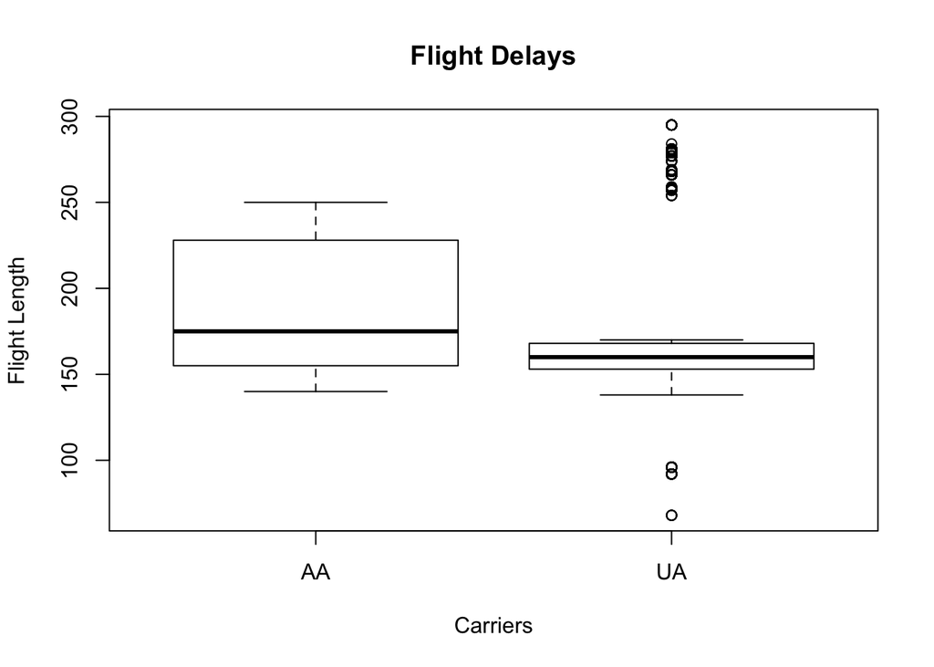

```r
boxplot(FlightLength~Carrier, data=df.delays, main="Flight Delays",ylab="Flight Length",xlab="Carriers")
```

Q5(5pts): Briefly explain what the boxplots show about the flight lengths of the carriers.

# The boxplots shows that the carrier AA has a higher median and higher upper & lower quartiles, yet contains no outliers. On the other hand carrier UA has a smaller median and lower quartiles and has many outliers.

Q6(8pts): Compute the total delay time (y axis) for each destination (x axis) and plot these values in a barplot. Add the title: Total Delay per Destination, and label the x and y axes appropriately. You can use the tapply function to do the sum of the Delays for each destination. Lookup the tapply function with ?tapply if necessary. The second parameter you pass in to tapply is the “index” or “grouping” column, in this case Destination. The tapply function will apply the sum to Delay grouping on the levels of Destination- very nifty!

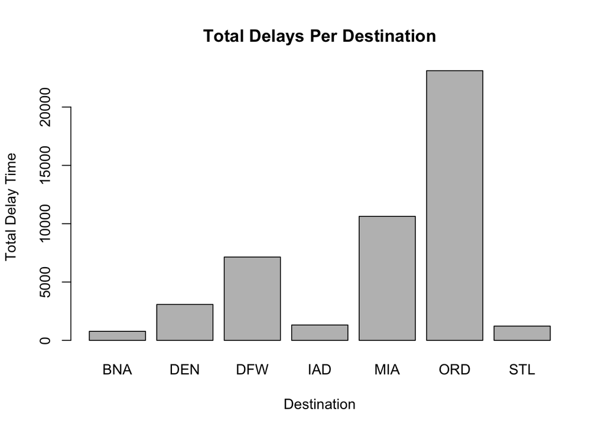

```r
barplot(tapply(df.delays$Delay,df.delays$Destination,sum), main="Total Delays Per Destination", xlab="Destination",ylab="Total Delay Time")
```

Q7(2pts): Alter the plot so that the delays are shown in ascending order- i.e. the longest delay is at the right. Hint: use “sort”.

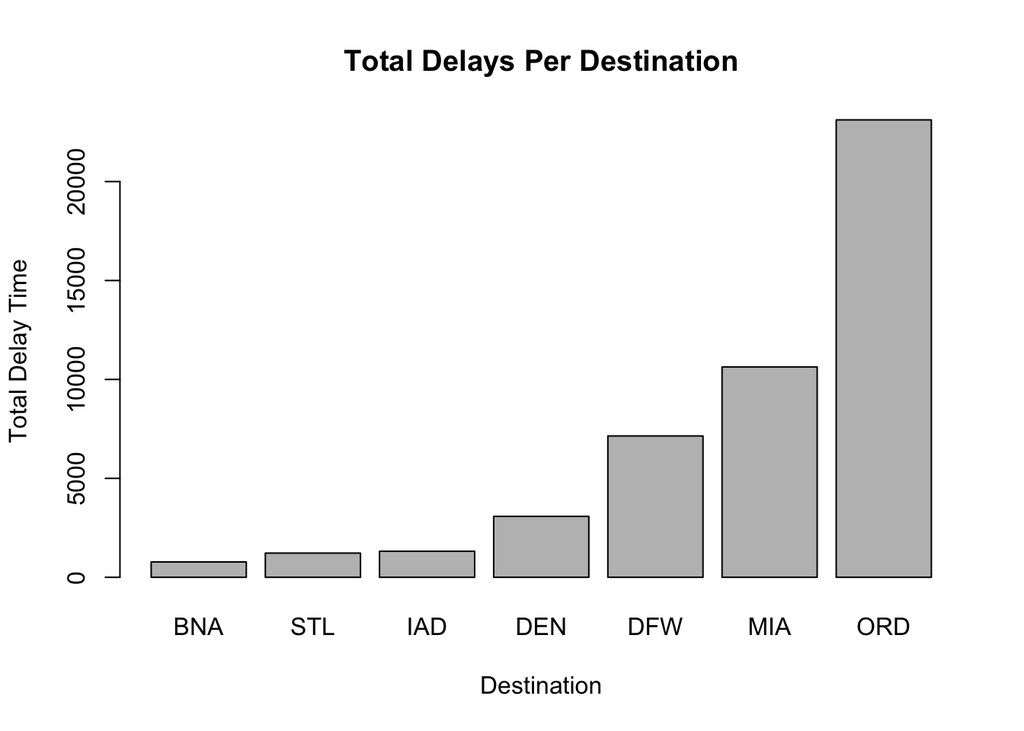

```r
delaydestt <- tapply(df.delays$Delay,df.delays$Destination,sum)
barplot(sort(delaydestt,decreasing=FALSE), main="Total Delays Per Destination", xlab="Destination",ylab="Total Delay Time")
```

#### Part 2: Analyzing categorical data for independence: contingency tables.

You will perform a contingency table analysis on two data sets.

##### Process data sets.

Q8(2pts): You will work with the “TestProcessAB” data set. This data set contains the results, “good” or “bad” of making items from two processes A and B. Write the statement that reads in the file “TestProcessAB.csv” and assigns it to a variable df.process.

```r
df.process<-read.table("TestProcessAB.csv", header = TRUE)
```

Q9(2pts): Create a table from the whole dataframe and assign it to a variable called cont.table and print the table to the console.

```r
cont.table <- data.frame(df.process)
```